# How does religion and science related in the field of Philosophy?

# Data processing and exploring by year

## How does the relationship between philosophy and science, religion change over time?

After analyzing the relationship for each school, it got us wondering that does the attitude toward science, religion change in the development of history?

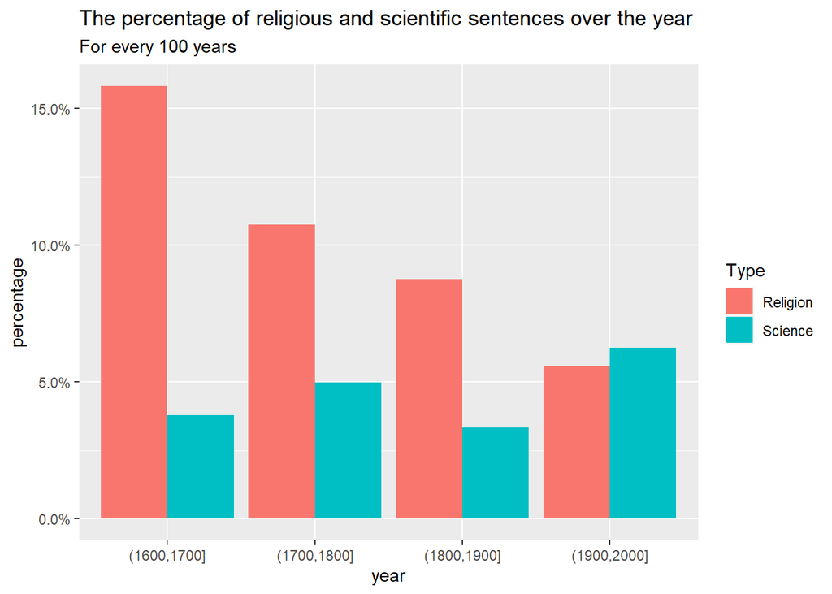

```r
year_count <- data%>%group_by(year)%>%summarise(count = n())%>%
  filter(year>1000)%>%
  mutate(year_level = cut(year,breaks = seq(-400,2000,100),include.lowest = T,
                          dig.lab = 5))%>%
  group_by(year_level)%>%summarise(count = sum(count))
rel_year_perc <- rel_sentence%>%group_by(year)%>%summarize(rel_count = n())%>%
  filter(year>1000)%>%
  mutate(year_level = cut(year,breaks = seq(-400,2000,100),include.lowest = T,
                          dig.lab = 5))%>%
  select(year_level, rel_count)%>%
  group_by(year_level)%>%summarise(rel_count = sum(rel_count))%>%
  left_join(year_count,by = "year_level")%>%
  mutate(rel_perc = rel_count/count)


sci_year_perc <- sci_sentence%>%group_by(year)%>%summarize(sci_count = n())%>%
  mutate(year_level = cut(year,breaks = seq(-400,2000,100),include.lowest = T,
                          dig.lab = 5))%>%
  select(year_level, sci_count)%>%
  group_by(year_level)%>%summarise(sci_count = sum(sci_count))%>%
  left_join(year_count,by = "year_level")%>%
  mutate(sci_perc = sci_count/count)

rel_year_perc%>%left_join(sci_year_perc,by = c("year_level", "count"))%>%
  select(year_level, rel_perc, sci_perc)%>%
  pivot_longer(cols = c("rel_perc", "sci_perc"))%>%
  ggplot(aes(x = year_level, y = value, fill = name)) + geom_col(position = "dodge")+
  scale_y_continuous(labels = scales::percent) +
  scale_fill_discrete(name = "Type", labels = c("Religion", "Science")) +
  labs(title = "The percentage of religious and scientific sentences over the year",
       subtitle = "For every 100 years", x = "year",
       y = "percentage")
```

The change in mind is not something that can happen in few years. Therefore, to explore the change of religion and science in the development of philosophy, we will divide the sentences every 100 years to see if there is a trend. From the graph, it is interesting that religion is always a hot topic for philosophy. Like mentioned in the introduction, there is a huge gap in the timeline between the year 200 to the year 1600. Therefore, it is reasonable that we only consider the year after 1600 to 2000. We can see that the percentage of sentences related to religion decreases as the year moves forwards from 15% to about 6%. Thus, even though religious topics are still important in the field of philosophy, the frequency of mentioning religion by philosophers is less and less as the time moves forward.

For the sentence related to science, even though the year from 1800 to 1900 is an outlier, we can still see that it also have a upward trend from about 4 percent to 6 percent. The graph shows that scientific topics are becoming more important in these 400 year.